# Tugas Khusus RB

| Field | Data |
| --- | --- |
| Nama | Farhan Apri Kesuma |
| NIM | 121140179 |

Membuat desain responsive halaman, dengan kriteria:

1. minimal ada 3 layout yang ditampilkan
2. ada 3 variasi ukuran layar: 1 ukuran handphone, table, pc/laptop
3. gunakan minimal 3 contoh elemen block dan 3 element inline pada desain halaman web
4. buat salah satu layout menggunakan properti flexbox parent

Ilustrasi Halaman web

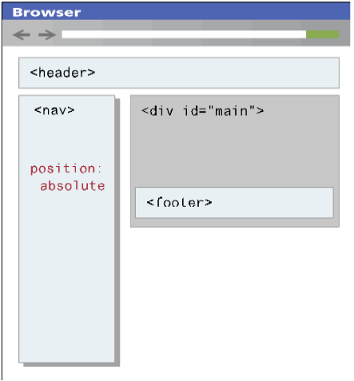

Ilustrasi desain responsif

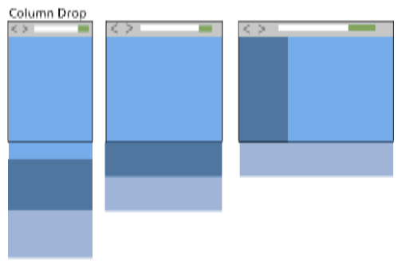

Format mengumpulkannya: nama-nim-tugas3.pdf

## Langkah Pertama: Membuat Berkas HTML `Index`, `Github`, dan `Skill`

## Langkah Kedua: Membuat Kerangka HTML pada `index.html` `github.html` dan `skill.html`

Membuat semua komponen yang dibutuhkan pada halaman home di `index.html` berikut kodenya:

1. Halaman Index

```
<!DOCTYPE html>
<html lang="en">
  <head>
    <meta charset="UTF-8" />
    <meta name="viewport" content="width=device-width, initial-scale=1.0" />
    <title>Farhan Apri Kesuma | Home</title>
    <link rel="stylesheet" href="assets/style.css" />
    <link rel="stylesheet" href="assets/profile.css" />
    <link rel="icon" href="assets/img/f-logo.png" />
    <link rel="stylesheet" href="https://cdnjs.cloudflare.com/ajax/libs/font-awesome/5.15.3/css/all.min.css" />
    <link rel="stylesheet" href="https://cdnjs.cloudflare.com/ajax/libs/font-awesome/6.0.0-beta3/css/all.min.css" />
  </head>
  <body>
    <header>
      <h1>Farhan Apri Kesuma</h1>
    </header>

    <div class="container">
      <nav class="sidebar">
        <h2>Menu</h2>
        <ul>
          <li><a class="active" href="#">Home</a></li>
          <li><a href="github.html">My Github</a></li>
          <li><a href="skill.html">Skills</a></li>
        </ul>
      </nav>

      <div class="main-content">
        <h1>Hello this is me Farhan!</h1>
        <div class="profile-card">
          <div class="profile-image">
            <img src="assets/img/profile-photo.png" alt="Profile Image" />
          </div>
          <div class="profile-info">
            <h2>Farhan Apri Kesuma</h2>
            <h2>Mahasiswa</h2>
            <p>Pemweb RB</p>
            <div class="social-links">
              <a href="https://github.com/parhannn/"><i class="fab fa-github"></i></a>
              <a href="https://www.instagram.com/prhnnn_ak/"><i class="fab fa-instagram"></i></a>
              <a href="https://www.linkedin.com/in/farhan-apri-kesuma/"><i class="fab fa-linkedin"></i></a>
            </div>
          </div>
        </div>
      </div>
    </div>

    <footer>
      <p>&copy; 2024 Farhan Apri Kesuma</p>
    </footer>
  </body>
</html>
```

2. Halaman My Github

```
<!DOCTYPE html>
<html lang="en">
  <head>
    <meta charset="UTF-8" />
    <meta name="viewport" content="width=device-width, initial-scale=1.0" />
    <title>Farhan Apri Kesuma | My Github</title>
    <link rel="stylesheet" href="assets/style.css" />
    <link rel="stylesheet" href="assets/github.css" />
    <link rel="icon" href="assets/img/f-logo.png" />
    <link rel="stylesheet" href="https://cdnjs.cloudflare.com/ajax/libs/font-awesome/5.15.3/css/all.min.css" />
    <link rel="stylesheet" href="https://cdnjs.cloudflare.com/ajax/libs/font-awesome/6.0.0-beta3/css/all.min.css" />
  </head>
  <body>
    <header>
      <h1>Farhan Apri Kesuma</h1>
    </header>

    <div class="container">
      <nav class="sidebar">
        <h2>Menu</h2>
        <ul>
          <li><a href="index.html">Home</a></li>
          <li><a class="active" href="#">My Github</a></li>
          <li><a href="skill.html">Skills</a></li>
        </ul>
      </nav>

      <div class="main-content">
        <div class="container-main">
          <aside class="card-profile">
            <div class="img-profile">
              <img src="assets/img/photo.png" alt="github photo" />
            </div>
            <div class="info-profile">
              <h2>Farhan Apri Kesuma</h2>
              <p>parhannn</p>
              <a href="https://github.com/parhannn/" class="link-github"> <i class="fab fa-github"></i> Github Saya </a>
            </div>
          </aside>

          <section class="list-repos">
            <div class="repos-card">
              <h3>Project-LosFilm</h3>
              <p>LosFilm is a mobile based application that has a lot of useful features. LosFilm is suitable for movie enthusiasts who want a variety of films from different genres.</p>
              <a href="https://github.com/parhannn/Project-LosFilm" class="link-repos"> <i class="fab fa-github"></i> Visit </a>
            </div>

            <div class="repos-card">
              <h3>my-github-list</h3>
              <p>My Github List is an user github list app that can show github user and add it to user favorite list. This app using retrofit to receive data from github API.</p>
              <br />
              <a href="https://github.com/parhannn/my-github-list" class="link-repos"> <i class="fab fa-github"></i> Visit </a>
            </div>

            <div class="repos-card">
              <h3>HiBeauty (forked)</h3>
              <p>HiBeauty is a Bangkit Capstone Project</p>
              <br /><br />
              <a href="https://github.com/Martinexe4/HiBeauty" class="link-repos"> <i class="fab fa-github"></i> Visit </a>
            </div>

            <div class="repos-card">
              <h3>portofolio-sederhana</h3>
              <p>-</p>
              <br /><br /><br />
              <a href="https://github.com/parhannn/portofolio-sederhana" class="link-repos"> <i class="fab fa-github"></i> Visit </a>
            </div>
          </section>
        </div>
      </div>
    </div>

    <footer>
      <p>&copy; 2024 Farhan Apri Kesuma</p>
    </footer>
  </body>
</html>
```

3. Halaman Skills

```
<!DOCTYPE html>
<html lang="en">
  <head>
    <meta charset="UTF-8" />
    <meta name="viewport" content="width=device-width, initial-scale=1.0" />
    <title>Farhan Apri Kesuma | Skills</title>
    <link rel="stylesheet" href="assets/style.css" />
    <link rel="stylesheet" href="assets/skill.css" />
    <link rel="icon" href="assets/img/f-logo.png" />
    <link rel="stylesheet" href="https://cdnjs.cloudflare.com/ajax/libs/font-awesome/5.15.3/css/all.min.css" />
    <link rel="stylesheet" href="https://cdnjs.cloudflare.com/ajax/libs/font-awesome/6.0.0-beta3/css/all.min.css" />
    <link rel="stylesheet" type="text/css" href="https://cdn.jsdelivr.net/gh/devicons/devicon@latest/devicon.min.css" />
  </head>
  <body>
    <header>
      <h1>Farhan Apri Kesuma</h1>
    </header>

    <div class="container">
      <nav class="sidebar">
        <h2>Menu</h2>
        <ul>
          <li><a href="index.html">Home</a></li>
          <li><a href="github.html">My Github</a></li>
          <li><a class="active" href="#">Skills</a></li>
        </ul>
      </nav>

      <div class="main-content">
        <div class="container-skills">
          <div class="card-skill">
            <i class="fas fa-pencil-ruler"></i>
            <h3>Web/App Design</h3>
            <p>Desain web dan aplikasi yang modern dan responsif, memberikan pengalaman pengguna yang luar biasa.</p>
          </div>

          <div class="card-skill">
            <i class="fas fa-code"></i>
            <h3>Web Development</h3>
            <p>Membangun website yang handal, aman, dan scalable dengan teknologi terbaru.</p>
          </div>

          <div class="card-skill">
            <i class="fas fa-mobile-alt"></i>
            <h3>Mobile Dev</h3>
            <p>Mengembangkan aplikasi mobile yang berkinerja tinggi untuk berbagai platform.</p>
          </div>

          <div class="card-skill">
            <i class="fas fa-bullhorn"></i>
            <h3>Personal Branding</h3>
            <p>Membantu dalam membangun citra diri yang kuat untuk meningkatkan kepercayaan dan profesionalisme.</p>
          </div>

          <div class="card-skill">
            <i class="fas fa-language"></i>
            <h3>English</h3>
            <p>Kemampuan bahasa Inggris yang baik untuk komunikasi profesional dalam skala global.</p>
          </div>

          <div class="card-skill">
            <i class="fas fa-lightbulb"></i>
            <h3>Work Smart</h3>
            <p>Menggunakan pendekatan kerja yang efisien dan efektif untuk mencapai hasil maksimal.</p>
          </div>
        </div>
      </div>
    </div>

    <footer>
      <p>&copy; 2024 Farhan Apri Kesuma</p>
    </footer>
  </body>
</html>
```

Setelah kerangka sudah selesai dibuat beserta selector-nya, lanjut membuat berkas `.css` pada folder `assets`, tidak lupa menambahkan juga aset gambar untuk ditampilkan di halaman web. Berikut susunan file-nya.

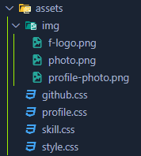

Setelah itu, saya lakukan styling pada `index.html` `github.html` dan `skill.html` dengan css berikut:

1. CSS Style Keseluruhan

```
@import url("https://fonts.googleapis.com/css?family=Poppins:400,500,600,700&display=swap");

* {
  margin: 0;
  padding: 0;
  box-sizing: border-box;
}

body {
  font-family: "Poppins", sans-serif;
  display: flex;
  min-height: 100vh;
  flex-direction: column;
  background-color: #F4F6FF;
}

header {
  background-color: #4070f4;
  color: white;
  padding: 20px;
  width: 100%;
  position: relative;
  z-index: 1;
  transition: all 0.3s ease;
}

.container {
  display: flex;
  flex: 1;
  width: 100%;
}

.sidebar {
  background-color: #4070f4;
  color: white;
  width: 250px;
  padding: 20px;
  height: 100vh;
}

.sidebar h2 {
  margin-bottom: 20px;
}

.sidebar ul {
  list-style-type: none;
  padding-left: 0;
}

.sidebar ul li {
  margin-bottom: 10px;
}

.sidebar ul li a {
  color: white;
  text-decoration: none;
  align-items: center;
  padding: 10px;
  font-size: 18px;
  display: flex;
  transition: all 0.3s ease;
}

.sidebar ul li a:hover,
a.active {
  background-color: #0e4bf1;
  border-radius: 5px;
  padding-left: 10px;
}

.main-content {
  padding: 20px;
  flex: 1;
}

.main-content h1 {
  margin-bottom: 20px;
}

footer {
  background: #4070f4;
  color: white;
  text-align: center;
  padding: 20px 0;
}

@media screen and (max-width: 1024px) {
  .container {
    flex-direction: column;
  }

  .sidebar {
    width: 100%;
    height: auto;
  }

  h1 {
    font-size: 23px;
    text-align: center;
  }
}

::-webkit-scrollbar {
  width: 12px;
}

::-webkit-scrollbar-track {
  background-color: rgb(53, 160, 242);
}

::-webkit-scrollbar-thumb {
  background-color: rgb(221, 240, 255);
}

::-webkit-scrollbar-thumb:hover {
  background-color: rgb(0, 130, 230);
}

::-webkit-scrollbar-thumb:active {
  background-color: rgb(20, 141, 230);
}
```

2. CSS Style Halaman Home (Isi Profile)

```
.profile-card {
  display: flex;
  border-radius: 10px;
  height: 400px;
  overflow: hidden;
  box-shadow: 2px 6px 12px rgba(0, 0, 0, 0.1);
  background-color: white;
  margin: 20px auto;
}

.profile-image {
  width: 30%;
  height: 100%;
}

.profile-image img {
  width: 100%;
  height: 100%;
  object-fit: cover;
}

.profile-info {
  padding: 10px;
  width: 60%;
}

.profile-info h2 {
  margin: 10px 0 10px 10px;
  font-size: 40px;
  color: #333;
}

.profile-info p {
  margin: 10px 0 40px 10px;
  font-size: 28px;
  color: #666;
}

.social-links a {
  text-decoration: none;
  color: #0077b5;
  font-size: 14px;
  display: block;
}

.social-links {
  margin: 20px 0 0 10px;
  display: flex;
  gap: 15px;
}

.social-links a {
  text-decoration: none;
  font-size: 100px;
}

.social-links a .fa-github {
  color: #333;
  margin-right: 30px;
}

.social-links a .fa-linkedin {
  color: #0077b5;
  margin-right: 30px;
}

.social-links a .fa-instagram {
  color: #e4405f;
  margin-right: 30px;
}

.social-links a:hover {
  opacity: 0.7;
  transition: opacity 0.5s;
  background: none;
}

@media (max-width: 835px) {
  .profile-card {
    flex-direction: column;
    width: 90%;
    height: 100%;
    margin: 20px auto;
  }

  .profile-image {
    width: 100%;
  }

  .profile-info {
    padding: 20px;
  }

  .profile-info h2 {
    margin: 10px 0;
    font-size: 24px;
  }

  .profile-info p {
    margin: 10px 0;
    font-size: 18px;
  }

  .social-links {
    margin: 10px 0 0 0;
  }

  .social-links a {
    font-size: 40px;
  }

  .social-links a .fa-github {
    margin-right: 0;
  }

  .social-links a .fa-linkedin {
    margin-right: 0;
  }

  .social-links a .fa-instagram {
    margin-right: 0;
  }
}
```

3. CSS Styling Halaman My Github

```
.container-main {
  display: flex;
  justify-content: space-between;
  padding: 10px;
}

.card-profile {
  width: 30%;
  background-color: white;
  border-radius: 10px;
  box-shadow: 0 4px 8px rgba(0, 0, 0, 0.1);
  padding: 20px;
  display: flex;
  flex-direction: column;
  align-items: center;
}

.img-profile img {
  width: 120px;
  height: 120px;
  margin: 7vh 0 0 0;
  object-fit: cover;
  border-radius: 50%;
}

.info-profile h2 {
  margin-top: 15px;
  font-size: 24px;
  color: #333;
  text-align: center;
}

.info-profile p {
  margin-top: 5px;
  font-size: 18px;
  color: #666;
  text-align: center;
}

.link-github {
  text-decoration: none;
  color: #0077b5;
  font-size: 18px;
  margin: 15px 0 0 15%;
  display: inline-block;
  background-color: #f1f1f1;
  padding: 10px 20px;
  border-radius: 8px;
  box-shadow: 0 4px 8px rgba(0, 0, 0, 0.1);
  transition: background-color 0.3s;
}

.link-repos {
  text-decoration: none;
  color: #0077b5;
  font-size: 18px;
  margin: 15px 0 0 0;
  display: inline-block;
  background-color: #f1f1f1;
  padding: 10px 20px;
  border-radius: 8px;
  box-shadow: 0 4px 8px rgba(0, 0, 0, 0.1);
  transition: background-color 0.3s;
}

.link-github:hover {
  background-color: #e9e9e9;
}

.link-repos:hover {
  background-color: #e9e9e9;
}

.list-repos {
  display: grid;
  grid-template-columns: repeat(2, 1fr);
  gap: 20px;
  width: 65%;
}

.repos-card {
  background-color: white;
  border-radius: 10px;
  box-shadow: 0 4px 8px rgba(0, 0, 0, 0.1);
  padding: 20px;
  display: flex;
  flex-direction: column;
  align-items: flex-start;
}

.repos-card h3 {
  font-size: 20px;
  color: #333;
}

.repos-card p {
  margin: 5px 0 0 0;
  font-size: 16px;
  color: #666;
}

@media (max-width: 1024px) {
  .container-main {
    flex-direction: column;
    align-items: center;
  }

  .card-profile,
  .list-repos {
    width: 100%;
    margin-bottom: 20px;
  }

  .img-profile img {
    margin: 0 0 0 0;
  }

  .list-repos {
    grid-template-columns: 1fr;
  }
}
```

4. CSS Styling Halaman Skills

```
.container-skills {
  display: grid;
  grid-template-columns: repeat(3, 1fr);
  gap: 20px;
  max-width: 1200px;
  padding: 10px;
}

.sec-container-skills {
  display: grid;
  grid-template-columns: repeat(3, 1fr);
  gap: 20px;
  max-width: 1200px;
  margin: 0 auto;
  padding: 20px;
}

.third-container-skills {
  display: grid;
  grid-template-columns: repeat(3, 1fr);
  gap: 20px;
  max-width: 600px;
  margin: 0 auto;
  padding: 20px;
}

.align-center {
  text-align: center;
  margin: 20px 0 0 0;
}

.card-skill {
  background-color: white;
  border-radius: 10px;
  box-shadow: 0 4px 8px rgba(0, 0, 0, 0.1);
  padding: 20px;
  text-align: center;
  transition: all 0.3s ease;
}

.card-skill i {
  font-size: 40px;
  color: #0077b5;
  margin-bottom: 15px;
}

.card-skill h3 {
  font-size: 22px;
  color: #333;
  margin-bottom: 10px;
}

.card-skill p {
  font-size: 16px;
  color: #666;
}

.card-skill:hover {
  transform: translateY(-10px);
  box-shadow: 0 8px 16px rgba(0, 0, 0, 0.2);
}

.sec-card-skill {
  background-color: white;
  border-radius: 10px;
  box-shadow: 0 4px 8px rgba(0, 0, 0, 0.1);
  padding: 20px;
  text-align: center;
  transition: all 0.3s ease;
}

.sec-card-skill i {
  font-size: 40px;
  color: #0077b5;
  margin-bottom: 15px;
}

.sec-card-skill h3 {
  font-size: 22px;
  color: #333;
  margin-bottom: 10px;
}

.sec-card-skill p {
  font-size: 16px;
  color: #666;
}

.sec-card-skill:hover {
  transform: translateY(-10px);
  box-shadow: 0 8px 16px rgba(0, 0, 0, 0.2);
}

@media (max-width: 768px) {
  .container-skills {
    grid-template-columns: 1fr 1fr;
  }

  .sec-container-skills {
    grid-template-columns: 1fr 1fr;
  }

  .third-container-skills {
    grid-template-columns: 1fr 1fr;
  }
}

@media (max-width: 500px) {
  .container-skills {
    grid-template-columns: 1fr;
  }

  .sec-container-skills {
    grid-template-columns: 1fr;
  }

  .third-container-skills {
    grid-template-columns: 1fr;
  }
}
```

## Hasil Akhir Tampilan Halaman Web

Tampilan web memungkinkan tampilan responsif supaya isi konten tetap tampil dengan baik. Berikut hasil akhir tampilan pc/laptop, tablet, dan handphone.

### Tampilan PC/Laptop

[figure not shown]

[figure not shown]

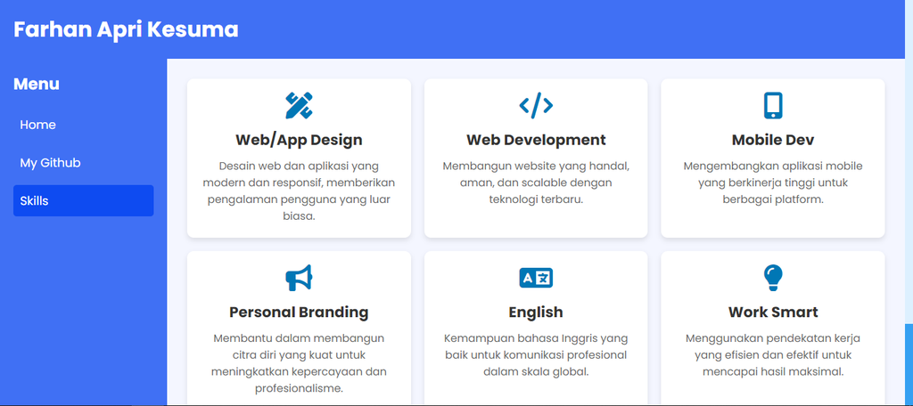

### Tampilan Tablet

[figure not shown]

[figure not shown]

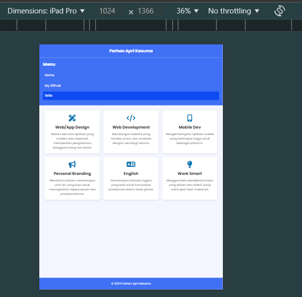

### Tampilan Handphone

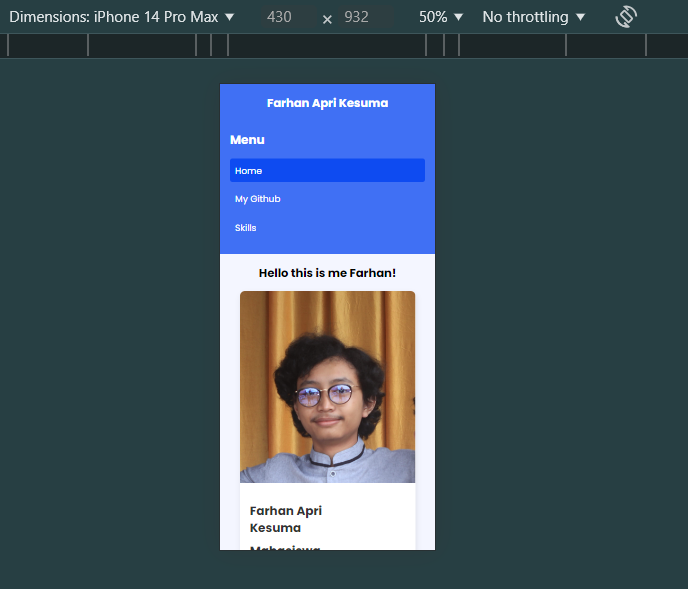

[figure not shown]

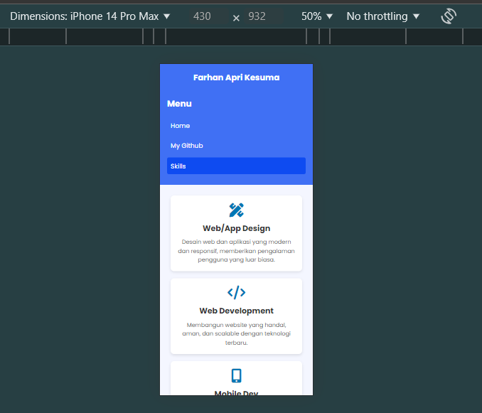

Jika ingin melihat *source code* dari web ini, bisa dengan mengakses repository Github di bawah ini dengan huruf bercetak tebal.

Repository `Tugas Khusus RB`: **tugas_3**